# Loan Prediction Machine Learning Project

PSTAT 131 Final Project

Alice Zhang

2023-03-24

# Introduction

This project tackles a binary classification problem: predicting loan eligibility based on select applicant data. I take a structured and analytical approach, incrementally traversing the data science life cycle and leveraging multiple techniques to yield the best model for the problem.

Data are pulled from [Kaggle](https://www.kaggle.com/datasets/vikasukani/loan-eligible-dataset) (originally sourced from an [Analytics Vidhya Hackathon](https://datahack.analyticsvidhya.com/contest/practice-problem-loan-prediction-iii/#ProblemStatement).

## Problem Statement

Loans are a necessity of the modern world, supporting financial stability and driving economic growth. Many types loans exist for different purposes, among which are home loans, which we intend to tackle in this problem.

Dream Housing Finance company deals in all home loans. They have a presence across all urban, semi-urban, and rural areas. Customers first apply for a home loan, after which the company assesses their eligibility.

The company aims to automate the loan eligibility process (real-time) based on customer details, such as gender, marital status, education, and income, provided in their application form.

The goal of this project is to identify customer segments that are most likely to be eligible for home loans, enabling the company to target these segments more efficiently. The company have provided a partial dataset to support the development of this model.

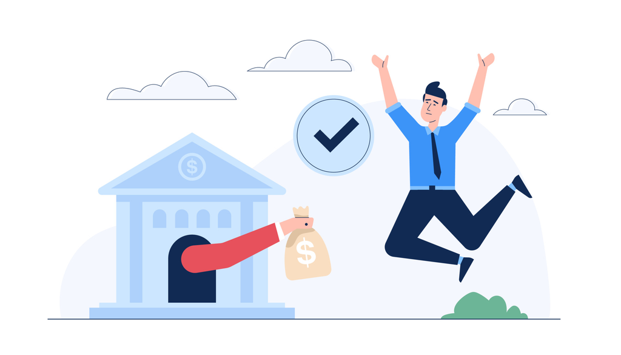

## Data Sources

The data files provided consists of a training set (train.csv) and test set (test.csv.). The test is identical to the training set except for the loan status to be predicted. The training set consists of 614 observations on 13 variables; the test set consists of 367 observations on 12.

As my project will apply supervised learning methods, I will only be using the training set. I will perform a 70/30 split on train.csv and utilize the response values to assess predictive accuracy.

## Project Roadmap

The project will follow a structured approach, starting with data collection and processing, followed by exploratory analysis, model training, and evaluation.

First, I will load the dataset into R, examine its structure, and perform initial data tidying, addressing missing values, duplicates, and inconsistencies. Next, I conduct exploratory data analysis (EDA), analyzing variables one by one to identify relationships and covariability, using these insights to guide further preprocessing. The dataset undergoes final tidying before model development.

Next, I split the data into train vs. test sets (70/30), create a preprocessing recipe, and establish validation sets (10) to optimize model selection and tuning. Models are trained and stored in separate RDA files before being loaded back in for evaluation. Performance is evaluated based on ROC-AUC, and the top 3 selected for testing. The project concludes with a detailed summary of my takeaways and findings.

# Data Processing

We begin by loading the data and examining its structure to identify errors and inconsistencies. We then perform initial tidying and feature engineering before exploring the dataset to inform further processing.

## Loading the data

```r
loan_ds <- read.csv("~/Desktop/School/PSTAT/PSTAT 131/proj-final/project_data/train.csv")
str(loan_ds)
```

```
## 'data.frame':    614 obs. of  13 variables:
##  $ Loan_ID          : chr  "LP001002" "LP001003" "LP001005" "LP001006" ...
##  $ Gender           : chr  "Male" "Male" "Male" "Male" ...
##  $ Married          : chr  "No" "Yes" "Yes" "Yes" ...
##  $ Dependents       : chr  "0" "1" "0" "0" ...
##  $ Education        : chr  "Graduate" "Graduate" "Graduate" "Not Graduate" ...
##  $ Self_Employed    : chr  "No" "No" "Yes" "No" ...
##  $ ApplicantIncome  : int  5849 4583 3000 2583 6000 5417 2333 3036 4006 12841 ...
##  $ CoapplicantIncome: num  0 1508 0 2358 0 ...
##  $ LoanAmount       : int  NA 128 66 120 141 267 95 158 168 349 ...
##  $ Loan_Amount_Term : int  360 360 360 360 360 360 360 360 360 360 ...
##  $ Credit_History   : int  1 1 1 1 1 1 1 0 1 1 ...
##  $ Property_Area    : chr  "Urban" "Rural" "Urban" "Urban" ...
##  $ Loan_Status      : chr  "Y" "N" "Y" "Y" ...
```

Note that:

- `Loan_ID`, a unique identifier for each applicant (primary key), is not relevant to our analysis (as we are interested in identifying customer segments)
- `Credit_History`, a categorical variable, is encoded as binary
- `ApplicantIncome` and `CoapplicantIncome` are monthly figures given in dollar amounts, while `LoanAmount` is given in terms of thousands. We will scale these features to ensure data consistency.

```r
colSums(is.na(loan_ds))
```

```
##           Loan_ID            Gender           Married        Dependents
##                 0                 0                 0                 0
##         Education     Self_Employed   ApplicantIncome CoapplicantIncome
##                 0                 0                 0                 0
##        LoanAmount  Loan_Amount_Term    Credit_History     Property_Area
##                22                14                50                 0
##       Loan_Status
##                 0
```

```r
sapply(loan_ds,function(x) table(as.character(x) =="")["TRUE"])
```

```
##           Loan_ID.NA          Gender.TRUE         Married.TRUE
##                   NA                   13                    3
##      Dependents.TRUE         Education.NA   Self_Employed.TRUE
##                   15                   NA                   32
##   ApplicantIncome.NA CoapplicantIncome.NA        LoanAmount.NA
##                   NA                   NA                   NA
##  Loan_Amount_Term.NA    Credit_History.NA     Property_Area.NA
##                   NA                   NA                   NA
##       Loan_Status.NA
##                   NA
```

The output reveals missingness is also present in `Gender`, `Married`, `Dependents`, and `Self-employed`. We will first encode these blanks into ‘NA’ for easy identification and determine how to handle them at a later step.

## Initial tidying

Reload the dataset, reading blank entries as ‘NA’.

```r
loan_ds <- read.csv(file="~/Desktop/School/PSTAT/PSTAT 131/proj-final/project_data/train.csv",
                    header=TRUE,na.strings = c("", NA))   # read blanks as NA's
```

Feature engineering: `ApplicantIncome` and `CoapplicantIncome`

- Scale features into thousands of dollars to match that of `LoanAmount`.

```r
loan_ds$ApplicantIncome <- (loan_ds$ApplicantIncome)/1000
loan_ds$CoapplicantIncome <- (loan_ds$CoapplicantIncome)/1000
```

Redundancy

- Remove `Loan_ID`, a unique identifier, since it is not relevant to our analysis.

```r
loan_ds <- loan_ds[,-1]; colnames(loan_ds)
```

```
##  [1] "Gender"            "Married"           "Dependents"
##  [4] "Education"         "Self_Employed"     "ApplicantIncome"
##  [7] "CoapplicantIncome" "LoanAmount"        "Loan_Amount_Term"
## [10] "Credit_History"    "Property_Area"     "Loan_Status"
```

## Data transformation

Encode categorical variables into factors.

```r
loan_ds$Gender <- factor(loan_ds$Gender, levels = c("Male","Female"))
loan_ds$Education <- factor(loan_ds$Education, levels = c("Graduate","Not Graduate"))
loan_ds$Self_Employed <- factor(loan_ds$Self_Employed, levels = c("Yes","No"))
loan_ds$Property_Area <- factor(loan_ds$Property_Area, levels = c("Rural","Semiurban","Urban"))
loan_ds$Loan_Status <- factor(loan_ds$Loan_Status, levels = c("Y","N"), labels = c("Yes","No"))
loan_ds$Credit_History <- factor(loan_ds$Credit_History, levels = c(1,0), labels = c("Yes","No"))
loan_ds$Dependents <- recode(loan_ds$Dependents,"3+"="3") %>%
  as.factor()
loan_ds$Married <- factor(loan_ds$Married)
```

## Missing values

Now, we can detect the correct level of missingness in all variables:

```r
colSums(is.na(loan_ds))   # validate results
```

```
##            Gender           Married        Dependents         Education
##                13                 3                15                 0
##     Self_Employed   ApplicantIncome CoapplicantIncome        LoanAmount
##                32                 0                 0                22
##  Loan_Amount_Term    Credit_History     Property_Area       Loan_Status
##                14                50                 0                 0
```

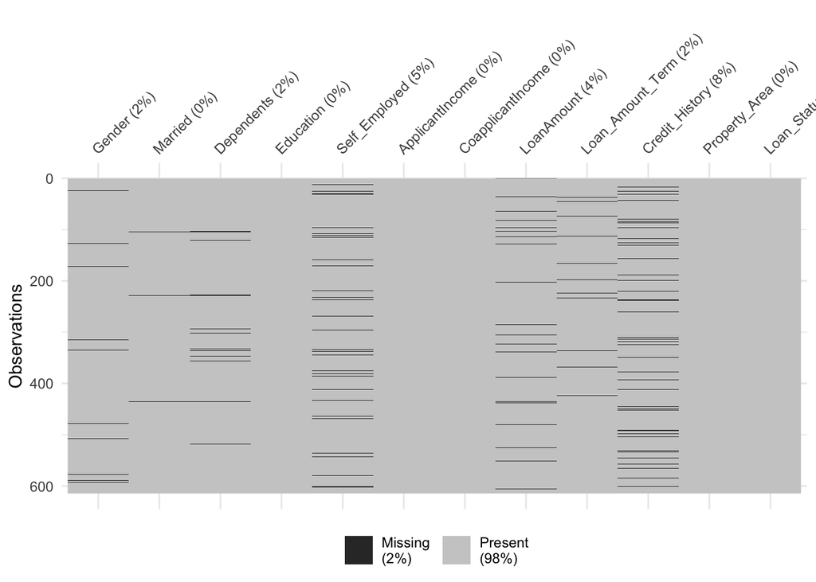

```r
vis_miss(loan_ds) # visualize missing data
```

The table below provides a numerical summary of missingness in our dataset, showing the # and percentage of missingness in each variable as well as a cumulative sum (running total).

```r
missingness <- loan_ds %>%
  miss_var_summary(add_cumsum = TRUE) %>%
  dplyr::arrange(n_miss_cumsum)

missingness
```

| variable | n_miss | pct_miss | n_miss_cumsum |
| --- | --- | --- | --- |
| Gender | 13 | 2.12 | 13 |
| Married | 3 | 0.489 | 16 |
| Dependents | 15 | 2.44 | 31 |
| Education | 0 | 0 | 31 |
| Self_Employed | 32 | 5.21 | 63 |
| ApplicantIncome | 0 | 0 | 63 |
| CoapplicantIncome | 0 | 0 | 63 |
| LoanAmount | 22 | 3.58 | 85 |
| Loan_Amount_Term | 14 | 2.28 | 99 |
| Credit_History | 50 | 8.14 | 149 |

[output cut: 2 more lines]

```r
sum(missingness$pct_miss)  # total % of missingness in dataset
```

```
## <pillar_num[1]>
## [1] 24.3
```

There are 149 total missing values (comprising ~24%) in our dataset.

How to address them?

- Remove all records with missing values
- Remove all variables with large amount of missingness (a set %)
- Impute missing values where appropriate

Methods 1 and 2 may result in incomplete data and are best avoided, especially with large amounts of missingness like our dataset. The best route is typically imputation, with a variety of methods to choose from.

However, neither of these options are appropriate at this stage in our analysis since we do not yet know which features are significant in prediction. We will leave the dataset as is and further explore the data before returning to address missing values at a later step.

Below is our final variable description, with the correct units and encoding.

## Variable description

- `Loan_ID` : Unique Loan ID.
- `Gender` : Male / Female.
- `Married` : Whether the applicant is married (Yes/No)
- `Dependents` : A factor indicating an applicant’s number of dependents (0,1,2,3).
- `Education` : An applicant’s education level (Graduate/Under Graduate)
- `Self_Employed` : Whether the applicant is self-employed (Yes/No)
- `ApplicantIncome` : An applicant’s monthly income (in thousands of dollars).
- `CoapplicantIncome` : A coapplicant’s monthly income (in thousands of dollars)
- `LoanAmount` : The loan amount requested by an applicant (in thousands of dollars).
- `Loan_Amount_Term` : The term of the loan in months.
- `Credit_History` : Whether the applicant’s credit history meet the bank’s requirements (Yes/No)
- `Property_Area` : An applicant’s area of residence (Urban/Semi Urban/Rural).
- `Loan_Status` : Whether the loan was approved or not (Yes/No).

# Exploratory Data Analysis

This section focuses on EDA, applying statistical analysis and data visualization techniques to explore trends, identify relationships, and infer causality, using these insights to inform further pre-processing.

We begin by examining the response and assessing correlation structures before analyzing features one by one to analyze variability and potential relationships.

## Loan Status

First, we will look at the distribution of the `Loan_Status` by creating a barplot.

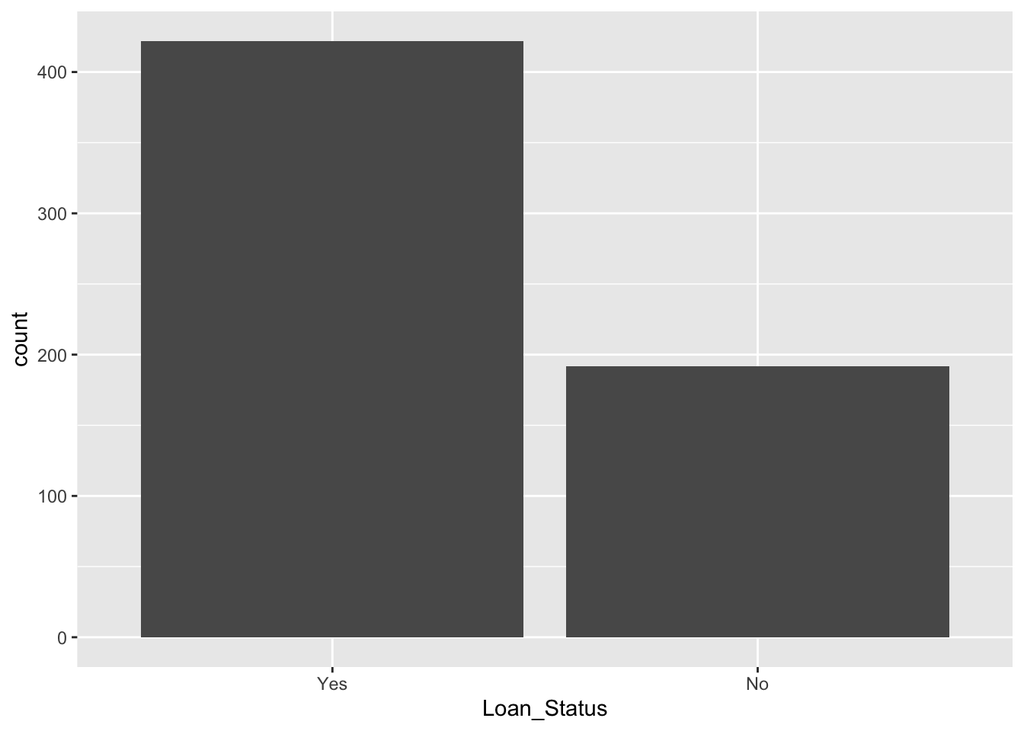

```r
loan_ds %>%
  ggplot(aes(x = Loan_Status)) +
  geom_bar() +
  theme_grey()  # create barplot
```

```r
loan_ds %>%
  select(Loan_Status) %>%
  table() %>%
  prop.table()
```

```
## Loan_Status
##       Yes        No
## 0.6872964 0.3127036
```

Approximately 69% of applicants were approved while 31% were rejected. This imbalance in classes may hinder our model performance. We will likely need to *upsample* or *downsample* the data at a later step.

## Correlation Analysis

Examining dependency among features is a crucial step in our analysis, providing insight into relationships, interactions, and helps detect potential issues such as multicolinearity.

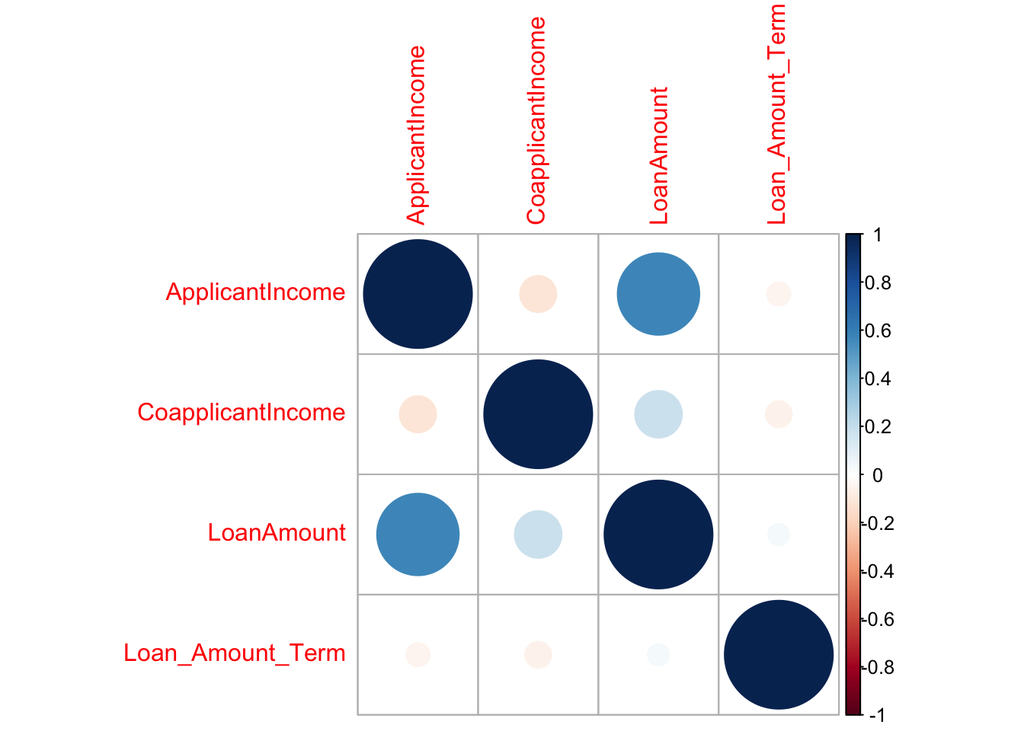

The plot below illustrates the magnitude of correlation coefficients.

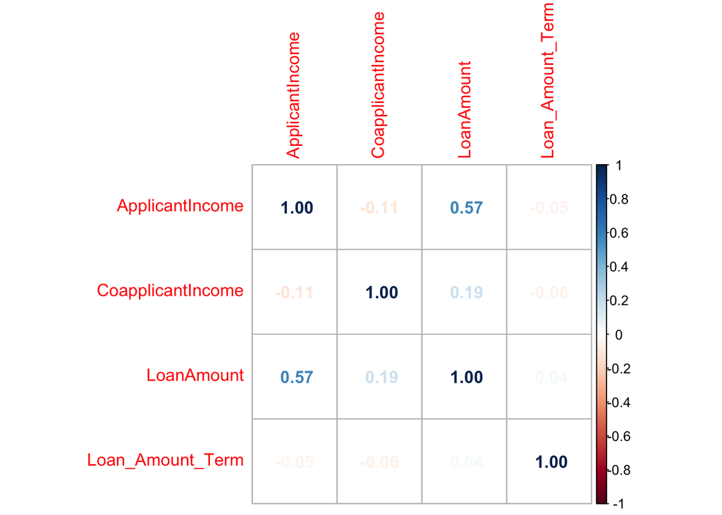

```r
loan_ds %>%
  select(where(is.numeric)) %>%
  na.omit() %>%
  cor() %>%
  corrplot(method="number")
```

We observe a moderate, positive correlation between `LoanAmount` and `ApplicantIncome` (0.57) with little correlation among the other numeric predictors. This is a good sign! We will keep these findings in mind as we explore the dataset.

## Feature Analysis

The next few sections will focus on analyzing individual and paired features, applying descriptive, visualization, and inferential techniques to infer relationships and causality.

### Loan Amount

The histogram below displays a right-skewed distribution, with most values falling between 0-400: a good proxy for the average loan amount requested by an applicant. We also observe a few high outliers pulling the mean up.

The paired box plots stratifies `Loan_Amount` by `Loan_Status`, providing further insight into dispersion and variability. While there is minimal variation in the average loan amount for approved and rejected applicants, we observe greater variability among the rejected applicants.

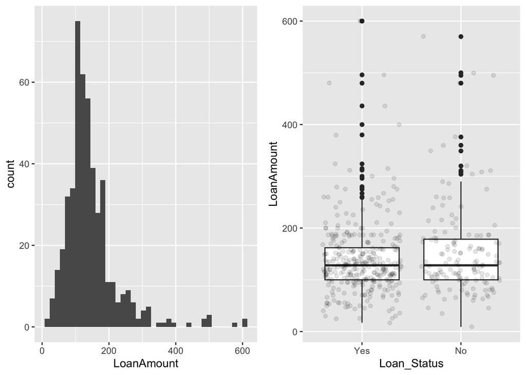

```r
require(gridExtra)

plot1 <- loan_ds %>%
  na.omit(LoanAmount) %>%
  ggplot(aes(x=LoanAmount)) +
  geom_histogram(bins=40) +
  theme_grey()

plot2 <- loan_ds %>%
  na.omit(LoanAmount) %>%
  ggplot(aes(Loan_Status, LoanAmount)) +
  geom_boxplot(na.rm=T) +
  geom_jitter(alpha = 0.1) +
  theme_grey()

grid.arrange(plot1, plot2, ncol=2)
```

```r
anova(aov(LoanAmount ~ Loan_Status, loan_ds))  # validate observations
```

|  | Df | Sum Sq | Mean Sq | F value | Pr(>F) |
| --- | --- | --- | --- | --- | --- |
| Loan_Status | 1 | 6028.895 | 6028.895 | 0.8227892 | 0.3647362 |
| Residuals | 590 | 4323158.537 | 7327.387 | NA | NA |

Next, we examine the relationship between `LoanAmount` and `ApplicantIncome`. Recall that these variables are positively correlated ($r = 0.57$). Ascatter plot of `LoanAmount` by `ApplicantIncome` shows an approximately linear trend, indicating that applicants with higher income tend to request larger loans. When stratifying applicants based on `Loan_Status` (the second plot), we observe similar approval rates across different loan amounts.

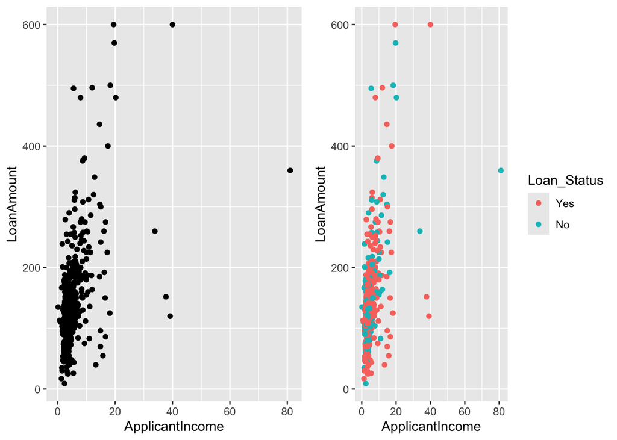

From these observations, it is difficult to discern whether `ApplicantIncome` is predictive of `Loan_Status`. This brings us to our next section.

### Applicant Income

```r
summary(loan_ds$ApplicantIncome)
```

```
##    Min. 1st Qu.  Median    Mean 3rd Qu.    Max.
##   0.150   2.877   3.812   5.403   5.795  81.000
```

The histogram below displays a right-skewed distribution: even with extreme outliers omitted (those exceeding 50 thousand), we observe an imbalance in the proportion of applicants within each income range. Average incomes among approved and rejected applicants are about the same.

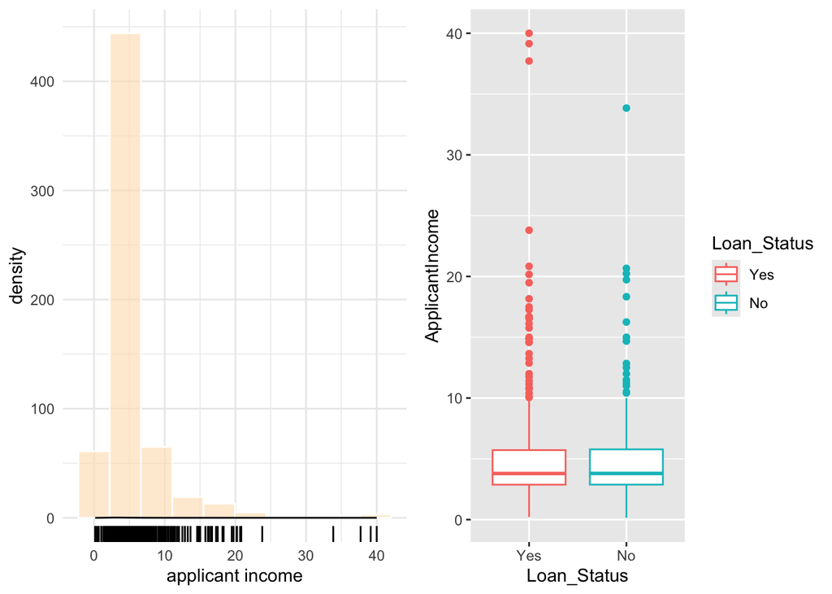

```r
plot1 <- loan_ds %>%
  filter(ApplicantIncome < 50) %>%    # filter by < 50 thousand
  ggplot(aes(x=ApplicantIncome)) +
  geom_histogram(fill="bisque",color="white",alpha=0.7, bins=10) +
  geom_density() +
  geom_rug() +
  labs(x = "applicant income") +
  theme_minimal()

plot2 <- loan_ds %>%
  filter(ApplicantIncome < 50) %>%
  ggplot(aes(y=ApplicantIncome,x=Loan_Status, color=Loan_Status))+
  geom_boxplot() +
  theme_grey()

grid.arrange(plot1, plot2, ncol=2)
```

Upon inspecting the three high outliers (`ApplicantIncome` > 50), we find that:

```r
loan_ds %>%
  filter(ApplicantIncome > 50)
```

| Gender | Married | Dependents | Education | Self_Employed | ApplicantIncome | CoapplicantIncome | LoanAmount | Loan_Amount_Term | Credit_History | Property_Area | Loan_Status |
| --- | --- | --- | --- | --- | --- | --- | --- | --- | --- | --- | --- |
| NA | Yes | 3 | Graduate | No | 51.763 | 0 | 700 | 300 | Yes | Urban | Yes |
| Male | Yes | 0 | Graduate | NA | 63.337 | 0 | 490 | 180 | Yes | Urban | Yes |
| Male | Yes | 3 | Graduate | No | 81.000 | 0 | 360 | 360 | No | Rural | No |

These observations suggest that neither `ApplicantIncome` or `LoanAmount` are very predictive of `Loan_Status` in the most extreme cases, seeing that the most affluent applicant requesting the smallest amount (last record) was rejected. From the trends observed above, we’d expect to see the opposite outcome: applicants with higher income and lower loan amount are more likely to be approved. They also suggest that `Property_Area` and `Credit_History` may be relevant factors independent of `ApplicantIncome`, seeing as the only rejected applicant resided in a rural area and had bad credit history. It’s difficult to discern whether `Education` or `Dependents` affect loan status. W will examine these factors in the next sections.

Now, let’s take a closer look at approval rates across different income strata. The table below bins applicants into income brackets defined in 5,000 increments, inclusive at the right end. We observe that applicants in the 4th bracket (15,000 to 20,000) have the highest approval rate, around 77%. This suggests that higher income somewhat correlates with a higher approval rate. However, it’s important to note that the number of data points in each bin varies, which may potentially inflate or deflate the approval rates.

| bin | Loan_Status | n | freq |
| --- | --- | --- | --- |
| (0,5] | Yes | 290 | 0.6855792 |
| (0,5] | No | 133 | 0.3144208 |
| (5,10] | Yes | 97 | 0.6978417 |
| (5,10] | No | 42 | 0.3021583 |
| (10,15] | Yes | 17 | 0.6296296 |
| (10,15] | No | 10 | 0.3703704 |
| (15,20] | Yes | 10 | 0.7692308 |
| (15,20] | No | 3 | 0.2307692 |
| (20,25] | Yes | 3 | 0.6000000 |
| (20,25] | No | 2 | 0.4000000 |

[output cut: 2 more lines]

### Coapplicant Income

We now turn to examine coapplicant incomes. Recall that a coapplicant income of 0 indicates no coapplicant.

A density plot grouped by `Loan_Status` indicates that coapplicant incomes are right skewed, with a mix of high and low values in each status category. Average coapplicant incomes for approved applicants are slightly higher than that of rejected applicants.

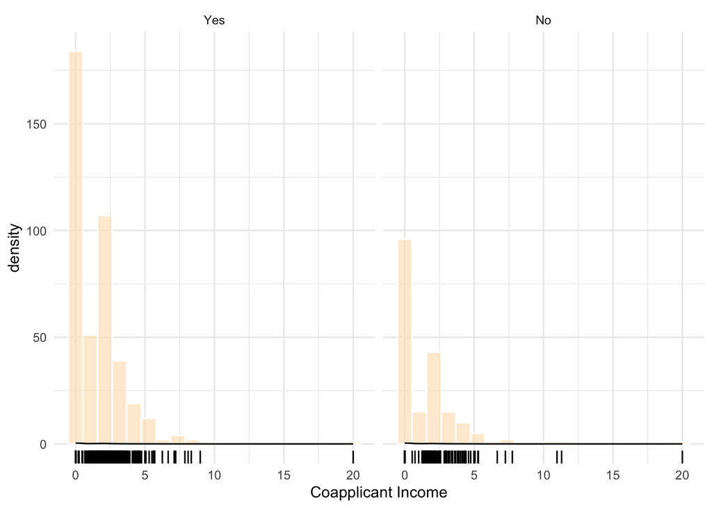

Trends are difficult to discern due to 0 `CoapplicantIncome` values (no applicant) skewing down the mean across both categories. The box plots below omits those values, providing better insight into its central tendency. Omitting high outliers (those > 30) would likely help too.

We observe that, of those with a coapplicant, approval rates are approximately equal.

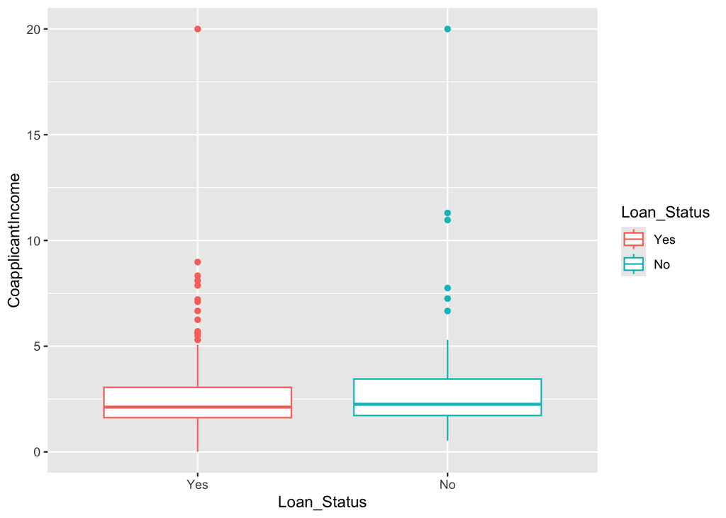

```r
loan_ds %>%
  filter((CoapplicantIncome != 0) & (CoapplicantIncome < 30)) %>%
  ggplot(aes(x=Loan_Status, y=CoapplicantIncome, color=Loan_Status)) +
  geom_boxplot()
```

What is more important? The presence of a coapplicant, or their income amount? We explore this question in the next section, first starting with a contingency table.

The table below shows that 273 out of 614 (about 44%) applicants do not have a coapplicant: a relatively large count.

```r
loan_ds %>%
  dplyr :: count(CoapplicantIncome == 0)
```

| CoapplicantIncome == 0 | n |
| --- | --- |
| FALSE | 341 |
| TRUE | 273 |

Now we stratify on an auxiliary variable `has_coapp`, with values FALSE if `CoapplicantIncome` is 0, and TRUE otherwise. The contingency table below indicates that applicants with coapplicants are more likely to be approved (71% vs 65%).

```r
loan_ds %>%
  dplyr:: mutate(has_coapp = if_else(CoapplicantIncome != 0,TRUE,FALSE)) %>%
  group_by(has_coapp, Loan_Status) %>%
  dplyr:: summarise(n=n()) %>%
  dplyr::mutate(freq = prop.table(n))
```

| has_coapp | Loan_Status | n | freq |
| --- | --- | --- | --- |
| FALSE | Yes | 177 | 0.6483516 |
| FALSE | No | 96 | 0.3516484 |
| TRUE | Yes | 245 | 0.7184751 |
| TRUE | No | 96 | 0.2815249 |

```r
# on average, ~72% of applicants w/ a coapplicant were approved for a loan
# while only ~65% of applicants w/o a coapplicant were approved.
```

These observations indicates that the presence of a coapplicant may be more predictive of `Loan_Status` than the absolute value of their income. We should consider transforming `CoapplicantIncome` into a factor.

### Loan Amount Term

`Loan_Amount_Term` provides the term of the loan in months. We observe a left skewed distribution, indicating that its mean (approximately 342 months) falls below than its median and mode. In these cases, the mode is more representative of its center.

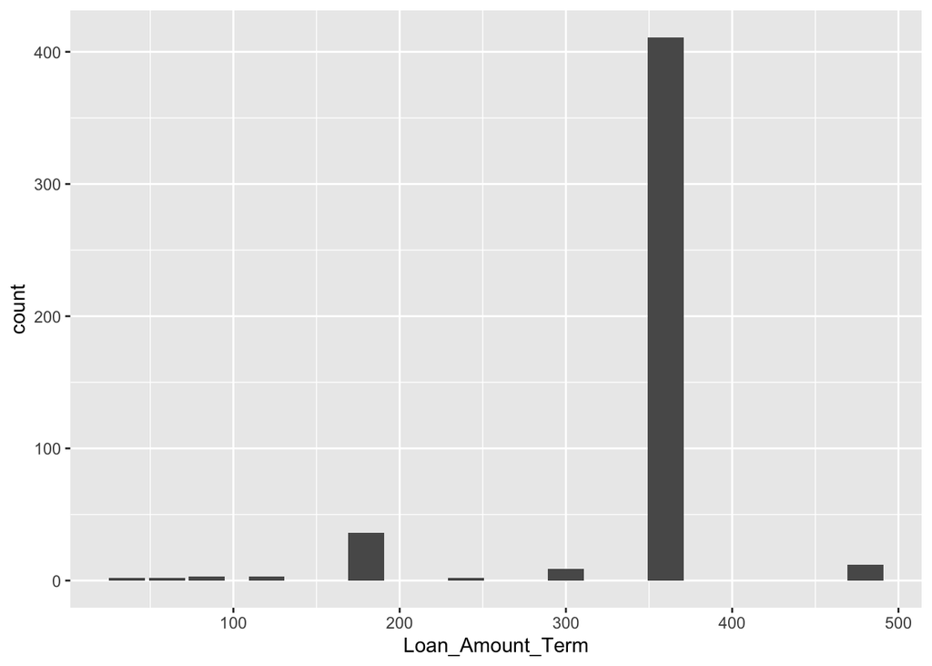

```r
loan_ds %>%
  na.omit(Loan_Amount_Term) %>%
  ggplot(aes(x=Loan_Amount_Term)) +
  geom_bar() +
  theme_grey() # mfv 360
```

We now look at `Loan_Amount_Term` in relation to `Loan_Status`. The plot below suggests that applicants requesting short-term loans are more likely to be approved, on average, than those requesting long-term loans. We do, however, observe a high approval rate for 360.

We should keep in mind that the data is very imbalanced, with ~85% of loans having a term of 360, likely under representing applicants with alternative loan terms.

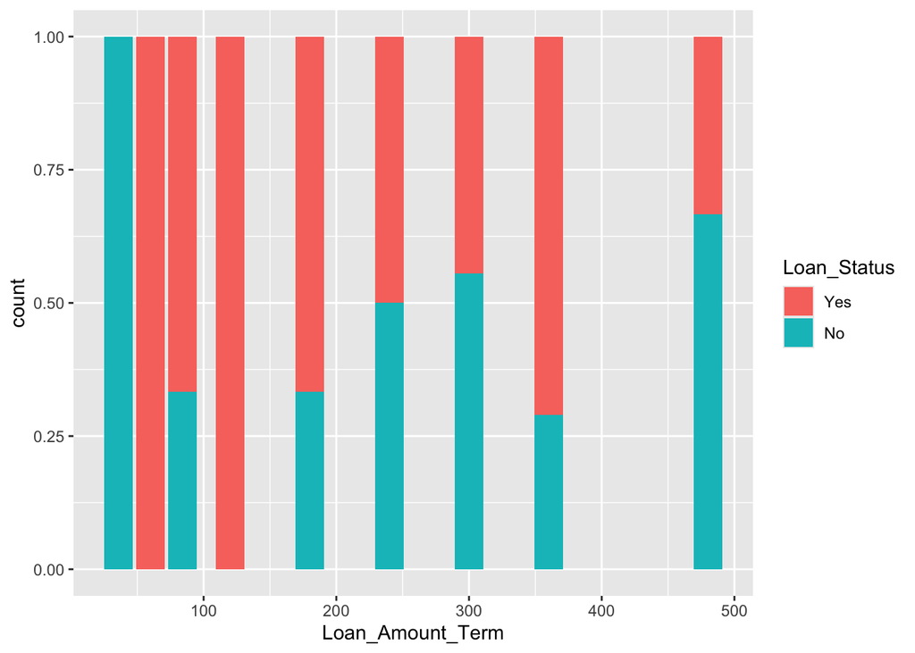

```r
loan_ds %>%
  na.omit(Loan_Amount_Term) %>%
  ggplot(aes(x=Loan_Amount_Term, fill=Loan_Status)) +
  geom_bar(position="fill")
```

### Dependents

Dependents is right skewed; most applicants have no dependents. Approval rates are similar across each category, with the highest approval rate for applicants with 2 dependents. There is no clear pattern, indicating that `Dependents` may not be very correlated with `Loan_Status`.

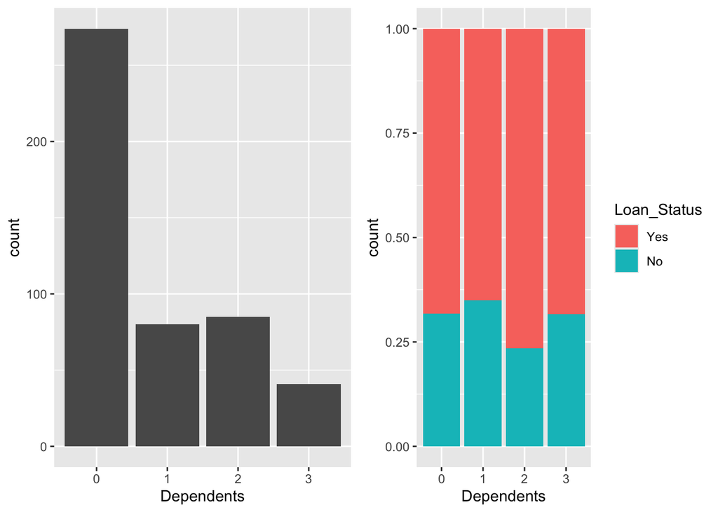

```r
plot1<-loan_ds %>%
  na.omit(Dependents) %>%  # should be able to impute this later
  ggplot(aes(x=Dependents)) +
  geom_bar()  # most applicants have no dependents

# dependents vs. loan status
plot2<-loan_ds %>%
  na.omit(Dependents) %>%
  ggplot(aes(x=Dependents, fill=Loan_Status)) +
  geom_bar(position="fill")
# relatively similar likelihood of approval for each # of dependents

grid.arrange(plot1,plot2,ncol=2)
```

A natural question is whether applicants with dependents (indicative of a larger household) request a larger loan (`LoanAmount`).

The boxplots below indeed suggest that individuals **with** dependents do, on average, request a larger loan amount; however, the actual number of dependents do not seem very significant.

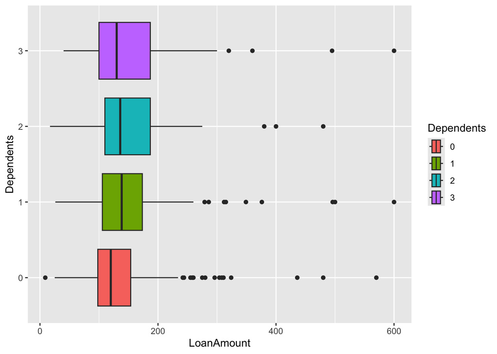

### Gender

There are more male applicants than female applicants (81% vs 19%), indicating an imbalance.

```r
prop.table(table(loan_ds$Gender))  # more males than females
```

```
##
##      Male    Female
## 0.8136439 0.1863561
```

A natural question to ask is whether there is bias in the selection process. From the plot below, we can see that females are indeed less likely (about 8% lower) to be approved for a loan than males. A 2-way contingency table also supports our hypothesis.

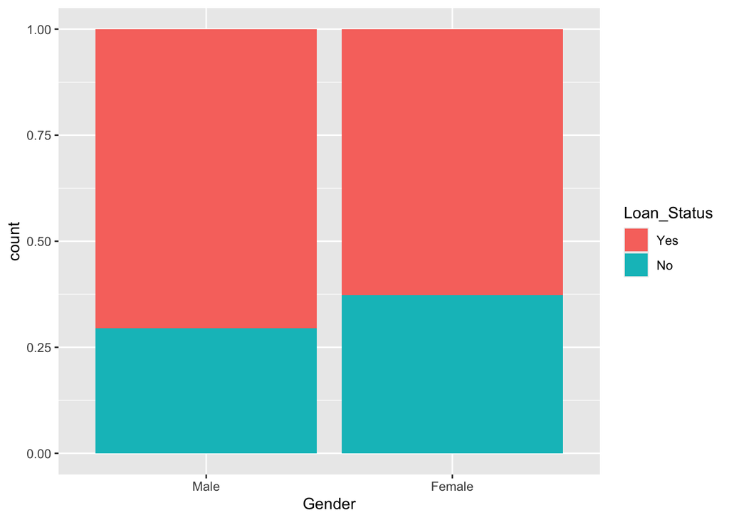

```r
loan_ds %>%
  na.omit(Gender) %>%  # should be able to impute this later
  ggplot(aes(x=Gender, fill=Loan_Status)) +
  geom_bar(position="fill")
```

```r
# 2-way contingency table
loan_ds %>%
  na.omit(Gender) %>%
  group_by(Gender, Loan_Status) %>%
  dplyr:: summarise(n=n()) %>%
  dplyr::mutate(freq = prop.table(n))
```

| Gender | Loan_Status | n | freq |
| --- | --- | --- | --- |
| Male | Yes | 278 | 0.7055838 |
| Male | No | 116 | 0.2944162 |
| Female | Yes | 54 | 0.6279070 |
| Female | No | 32 | 0.3720930 |

### Married

```r
prop.table(table(loan_ds$Married))
```

```
##
##        No       Yes
## 0.3486088 0.6513912
```

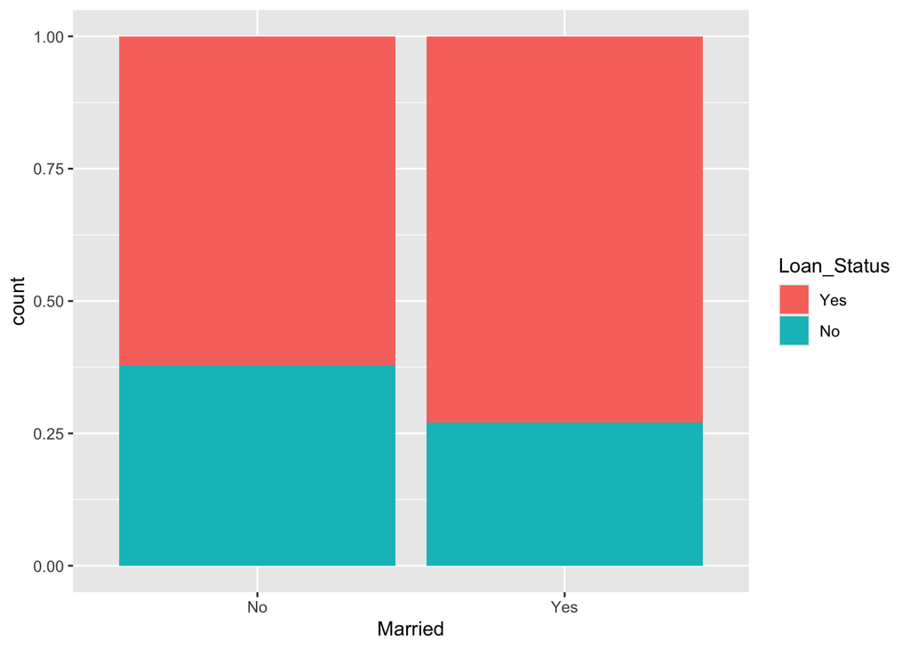

```r
loan_ds %>%
  na.omit(Married) %>%
  ggplot(aes(x=Married,fill=Loan_Status)) +
  geom_bar(position="fill")
```

```r
# 2-way contingency table
loan_ds %>%
  na.omit(Married) %>%
  group_by(Married, Loan_Status) %>%
  dplyr:: summarise(n=n()) %>%
  dplyr::mutate(freq = prop.table(n))
```

| Married | Loan_Status | n | freq |
| --- | --- | --- | --- |
| No | Yes | 105 | 0.6213018 |
| No | No | 64 | 0.3786982 |
| Yes | Yes | 227 | 0.7299035 |
| Yes | No | 84 | 0.2700965 |

### Education

`Education` is a factor representing an applicant’s educational level with levels “Graduate” or “Not Graduate”. Graduates comprise about 80% of our dataset, which makes sense given the weight of educational loans. An 80-20 ratio, however, is definitely unbalanced. From the barplots, we can see that graduates are more likely to get approved (8% more).

```r
prop.table(table(loan_ds$Education))
```

```
##
##     Graduate Not Graduate
##     0.781759     0.218241
```

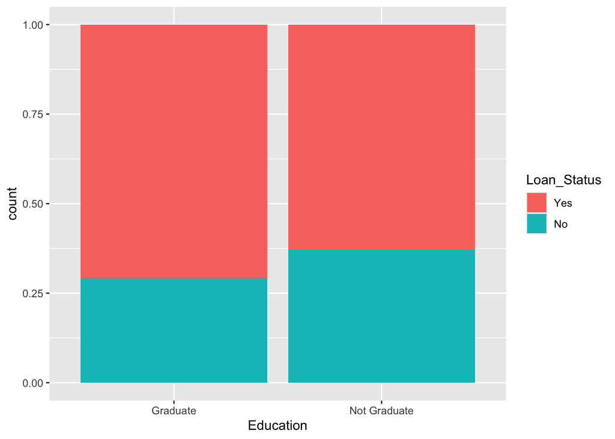

```r
loan_ds %>%
  na.omit(Education) %>%
  ggplot(aes(x=Education,fill=Loan_Status)) +
  geom_bar(position="fill")
```

```r
# 2-way contingency table
loan_ds %>%
  na.omit(Education) %>%
  group_by(Education, Loan_Status) %>%
  dplyr:: summarise(n=n()) %>%
  dplyr::mutate(freq = prop.table(n))
```

| Education | Loan_Status | n | freq |
| --- | --- | --- | --- |
| Graduate | Yes | 271 | 0.7075718 |
| Graduate | No | 112 | 0.2924282 |
| Not Graduate | Yes | 61 | 0.6288660 |
| Not Graduate | No | 36 | 0.3711340 |

### Self employed

`Self_Employed` is a factor indicating if an applicant is self-employed. Only 14% of applicants in the dataset are self-employed. There is no significant difference in the approval rates between self-employed and non self-employed individuals (~ 4%), with non self-employed individuals having the higher rate.

```r
prop.table(table(loan_ds$Self_Employed))
```

```
##
##       Yes        No
## 0.1408935 0.8591065
```

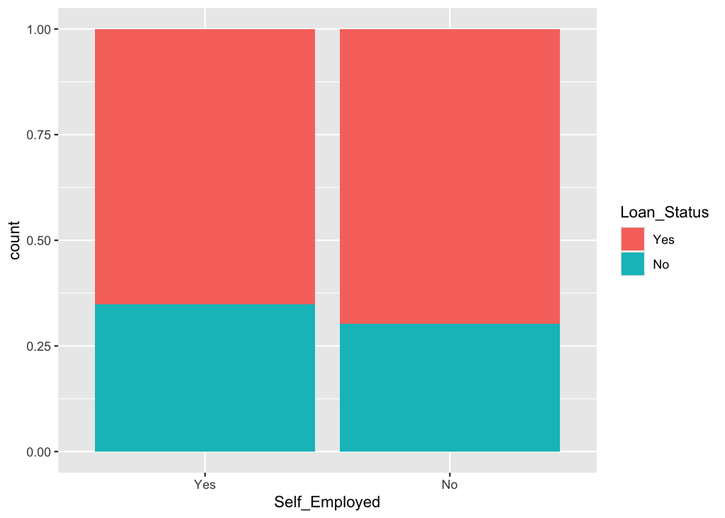

```r
loan_ds %>%
  na.omit(Self_Employed) %>%
  ggplot(aes(x=Self_Employed,fill=Loan_Status)) +
  geom_bar(position="fill")
```

```r
# 2-way contingency table
loan_ds %>%
  na.omit(Self_Employed) %>%
  group_by(Self_Employed, Loan_Status) %>%
  dplyr:: summarise(n=n()) %>%
  dplyr::mutate(freq = prop.table(n))
```

| Self_Employed | Loan_Status | n | freq |
| --- | --- | --- | --- |
| Yes | Yes | 43 | 0.6515152 |
| Yes | No | 23 | 0.3484848 |
| No | Yes | 289 | 0.6980676 |
| No | No | 125 | 0.3019324 |

### Credit History

`Credit_History` is a factor indicating whether an applicant’s credit meets the bank’s requirements. Most applicants have good credit history (~85%).

```r
prop.table(table(loan_ds$Credit_History))
```

```
##
##       Yes        No
## 0.8421986 0.1578014
```

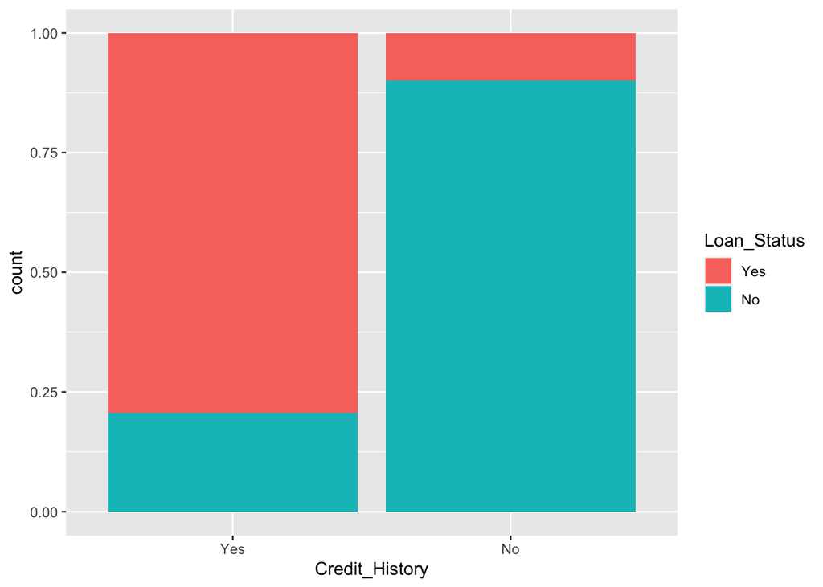

```r
loan_ds %>%
  na.omit(Credit_History) %>%
  ggplot(aes(x=Credit_History,fill=Loan_Status)) +
  geom_bar(position="fill")
```

Credit history appears to be a key determinant of loan eligibility, with nearly 80% of applicants with good credit history being approved (vs. 10% of those with poor credit). However, potential selection bias should be considered, as individuals with good credit may be more likely to apply in the first place.

```r
# 2-way contingency table
loan_ds %>%
  na.omit(Credit_History) %>%
  group_by(Credit_History, Loan_Status) %>%
  dplyr:: summarise(n=n()) %>%
  dplyr::mutate(freq = prop.table(n))
```

| Credit_History | Loan_Status | n | freq |
| --- | --- | --- | --- |
| Yes | Yes | 325 | 0.7926829 |
| Yes | No | 85 | 0.2073171 |
| No | Yes | 7 | 0.1000000 |
| No | No | 63 | 0.9000000 |

### Property Area

`Property_Area` is a factor representing the area in which an applicant resides: Urban, Semi Urban, or Rural. We have a good mix of applicants from all 3 areas, with thosing residing in semi urban areas having the highest approval rate.

```r
prop.table(table(loan_ds$Property_Area))
```

```
##
##     Rural Semiurban     Urban
## 0.2915309 0.3794788 0.3289902
```

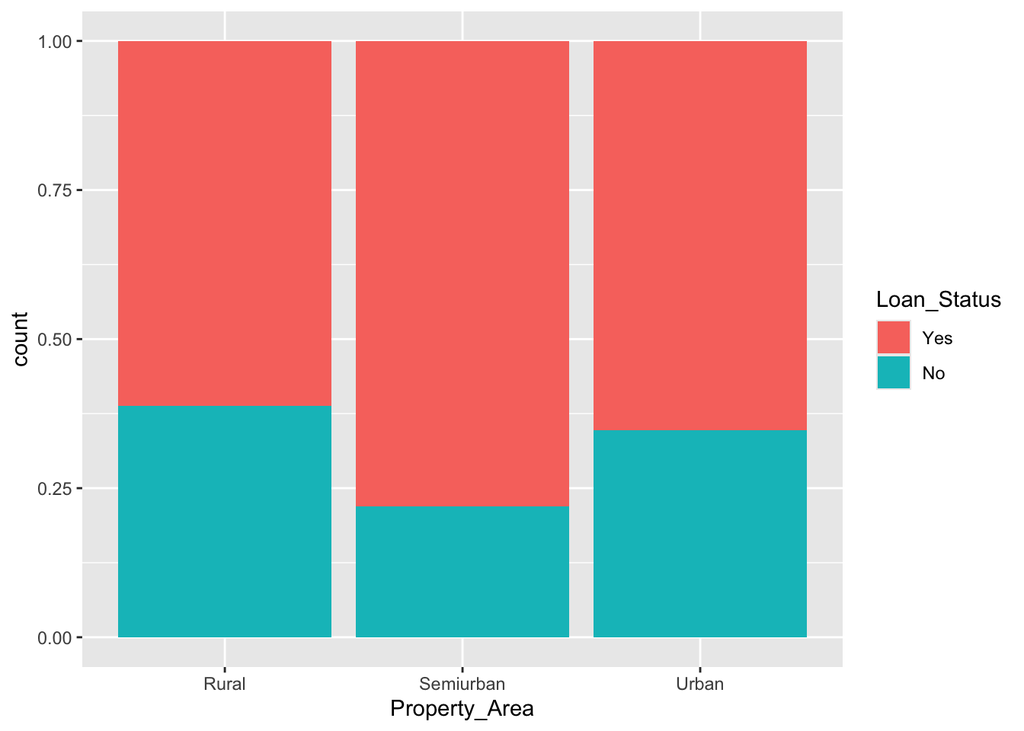

```r
loan_ds %>%
  na.omit(Property_Area) %>%
  ggplot(aes(x=Property_Area,fill=Loan_Status)) +
  geom_bar(position="fill")
```

```r
# 2-way contingency table
loan_ds %>%
  na.omit(Property_Area) %>%
  group_by(Property_Area, Loan_Status) %>%
  dplyr:: summarise(n=n()) %>%
  dplyr::mutate(freq = prop.table(n))
```

| Property_Area | Loan_Status | n | freq |
| --- | --- | --- | --- |
| Rural | Yes | 85 | 0.6115108 |
| Rural | No | 54 | 0.3884892 |
| Semiurban | Yes | 149 | 0.7801047 |
| Semiurban | No | 42 | 0.2198953 |
| Urban | Yes | 98 | 0.6533333 |
| Urban | No | 52 | 0.3466667 |

We also observe that married individuals tend to prefer semi urban areas over others. This is a pretty insightful finding because, as we recall, married individuals had a 10% higher approval rate than non-married individuals. Coupled with a higher approval rate for those with coapplicants, we may just find our target demographic!

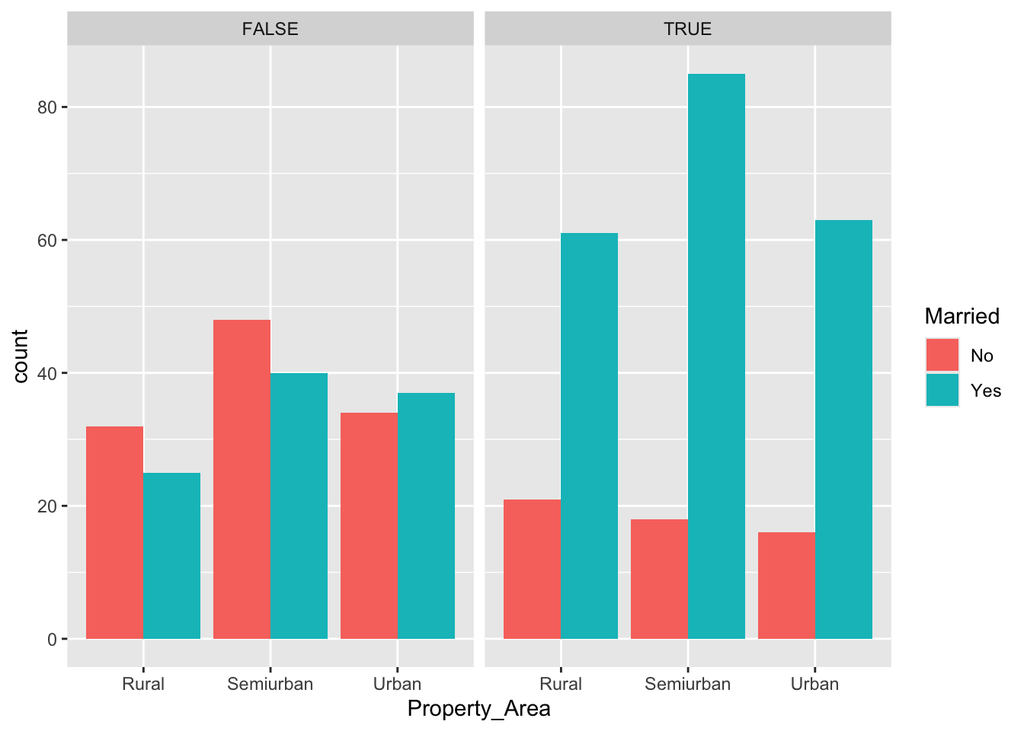

```r
# is property area related to any other predictors?
loan_ds %>%
  na.omit(Property_Area, Loan_Status, Married) %>%
  dplyr:: mutate(has_coapp = if_else(CoapplicantIncome != 0,TRUE,FALSE)) %>%
  ggplot(aes(x=Property_Area,fill=Married)) +
  geom_bar(position="dodge") +
  facet_wrap(~has_coapp)
```

## Final tidying

Now that we’ve explored the dataset, we will need to fix some errors before continuing with our analysis. Let’s review these issues:

- Missingness observed in 7 variables;
- Extreme high outliers observed in `ApplicantIncome` and `LoanAmount`.

### MICE

Missingness exists in both numerical and categorical variables. Therefore, we will be using the `mice` package, which imputes missing values with plausible data values inferred from other variables in the dataset.

```r
# install and load
# install.packages("mice")
library(mice)
```

From the table below, we see that the first two variables are missing a large proportion of its values, while the last five are missing none.

```r
loan_ds %>%
  miss_var_summary()
```

| variable | n_miss | pct_miss |
| --- | --- | --- |
| Credit_History | 50 | 8.14 |
| Self_Employed | 32 | 5.21 |
| LoanAmount | 22 | 3.58 |
| Dependents | 15 | 2.44 |
| Loan_Amount_Term | 14 | 2.28 |
| Gender | 13 | 2.12 |
| Married | 3 | 0.489 |
| Education | 0 | 0 |
| ApplicantIncome | 0 | 0 |
| CoapplicantIncome | 0 | 0 |

[output cut: 2 more lines]

Now, we import the `mice` package. The argument `m` indicates the number of multiple imputations (default 5). The `method` argument specifies the imputation method applied to all variables in the dataset. A separate method can also be specified for each variable.

We can control the `defaultMethod` used for different types of data. I will choose predictive mean matching for numeric data, logistic regression for 2-level (binary) factors, LDA for unordered factor data, and proportional odds for ordered factor data.

```r
library(mice)
imp <- mice(loan_ds, m=5, defautMethod = c("pmm","logreg", "lda", "polr"))
```

Here, we can see the actual imputations for `Dependents`:

```r
imp$imp$Dependents
```

|  | 1 | 2 | 3 | 4 | 5 |
| --- | --- | --- | --- | --- | --- |
| 103 | 0 | 0 | 0 | 2 | 2 |
| 105 | 0 | 2 | 0 | 0 | 0 |
| 121 | 0 | 0 | 0 | 0 | 1 |
| 227 | 3 | 2 | 1 | 1 | 0 |
| 229 | 0 | 0 | 0 | 0 | 0 |
| 294 | 0 | 0 | 0 | 0 | 0 |
| 302 | 0 | 0 | 0 | 3 | 0 |
| 333 | 0 | 0 | 0 | 0 | 0 |
| 336 | 1 | 0 | 1 | 2 | 3 |
| 347 | 1 | 0 | 0 | 0 | 3 |

[output cut: 5 more lines]

Now let’s merge the imputed data into our original dataset via the `complete()` function.

```r
loan_ds <- complete(imp,5)    # I chose the 5th round of data imputation
```

Applying `mix_var_summary` again, we can see that there are no missing data after the imputation:

```r
loan_ds %>%
  miss_var_summary()   # validate results
```

| variable | n_miss | pct_miss |
| --- | --- | --- |
| Gender | 0 | 0 |
| Married | 0 | 0 |
| Dependents | 0 | 0 |
| Education | 0 | 0 |
| Self_Employed | 0 | 0 |
| ApplicantIncome | 0 | 0 |
| CoapplicantIncome | 0 | 0 |
| LoanAmount | 0 | 0 |
| Loan_Amount_Term | 0 | 0 |
| Credit_History | 0 | 0 |

[output cut: 2 more lines]

### Outliers

Outliers can be tricky to interpret, as they may result from data entry errors, sampling issues, or natural variability within the dataset. Removing them risks potential information loss. For now, we will assume that missing values are systematic unless proven otherwise.

```r
zscore <- (abs(loan_ds$LoanAmount-mean(loan_ds$LoanAmount, na.rm=T))/sd(loan_ds$LoanAmount, na.rm=T))
loan_ds$LoanAmount[which(zscore > 3)]
```

```
##  [1] 650 600 700 495 436 600 480 490 570 500 480 480 600 496
```

Since we have a positive skew, we will perform a log transformation to normalize the data. Now the data looks closer to normal and the effect of extreme outliers are significantly smaller.

```r
loan_ds$LogLoanAmount <- log(loan_ds$LoanAmount)
```

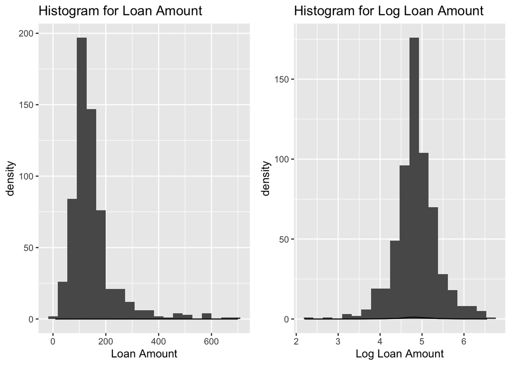

```r
plot1 <- loan_ds %>%
  ggplot(aes(x=LoanAmount)) +
  geom_histogram(bins=20) +
  geom_density()+
  labs(title="Histogram for Loan Amount") +
  xlab("Loan Amount")

plot2 <- loan_ds %>%
  ggplot(aes(x=LogLoanAmount)) +
  geom_histogram(bins=20) +
  geom_density()+
  labs(title="Histogram for Log Loan Amount") +
  xlab("Log Loan Amount")

grid.arrange(plot1,plot2,ncol=2)
```

We also have a pretty severe positive skew for `ApplicantIncome`, so we will perform a log transformation as well. The data looks much better.

```r
loan_ds$LogApplicantIncome <- log(loan_ds$ApplicantIncome)
```

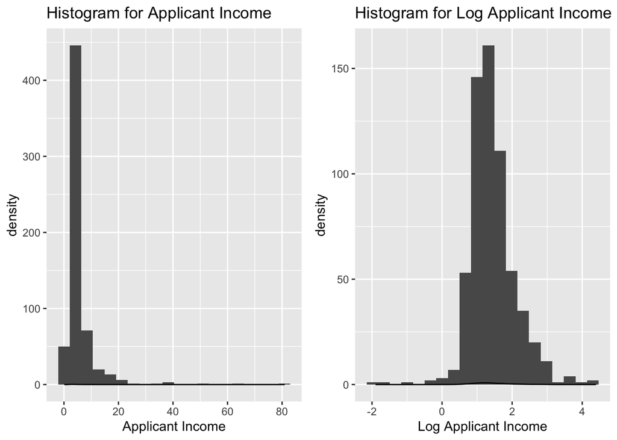

```r
plot1 <- loan_ds %>%
  ggplot(aes(x=ApplicantIncome)) +
  geom_histogram(bins=20) +
  geom_density()+
  labs(title="Histogram for Applicant Income") +
  xlab("Applicant Income")

plot2 <- loan_ds %>%
  ggplot(aes(x=LogApplicantIncome)) +
  geom_histogram(bins=20) +
  geom_density()+
  labs(title="Histogram for Log Applicant Income") +
  xlab("Log Applicant Income")

grid.arrange(plot1,plot2,ncol=2)
```

Now, we will remove the original variables from our dataset

```r
loan_ds <- select(loan_ds,-LoanAmount)  # remove original variable
loan_ds <- select(loan_ds,-ApplicantIncome)  # remove original variable
```

# Model Setup

Now that we have a better understanding of our dataset, it’s time to set up our models. We will perform a train vs. test split, create a preprcoessing recipe, then establish 10-fold cross-validation for model selection and tuning.

## Train/test Split

Here, we split the dataset into training and test sets using a 70/30 split, ensuring enough data for evaluation while maintaining a robust training set. To ensure replicability, we set a random seed and stratify on the response variable. Models will be trained and evaluated on the training set, then validated on previously unseen test data.

```r
set.seed(3450)
loan_split <- initial_split(loan_ds, prop = 0.70,
                              strata = "Loan_Status")

loan_train <- training(loan_split)
loan_test <- testing(loan_split)
loan_folds <- vfold_cv(loan_train, v = 10, strata = "Loan_Status")
```

Dimensions of our datasets:

```r
dim(loan_train); dim(loan_test)
```

```
## [1] 429  12
```

```
## [1] 185  12
```

## Building the recipe

Now that we’ve completed all the preliminary steps, it’s time to build our recipe. Think of it as baking cut-out cookies: while we’ll be using different molds (models), the base ingredients remain the same.

That’s what this recipe is; a unique mix of ingredients that will be fitted to different molds. Our goal is to identify the best mold for our particular mix. From there, fitting the best model to the test data is like using a new batch of ingredients (test data), shaping it with our chosen mold, and baking it to perfection!

In our recipe, we’ll be using 8 out of the 11 original predictors, 2 transformed variables `LogLoanAmount` and `LogApplicantIncome`, plus a new variable `Coapplicant` indicating the persence or absence of a coappliant.

Recall from earlier steps that our response is severely imbalanced, which can bias our models towards the majority class. To mitigate this, we’ll upsample the minority class using `step_upsample()` to ensure equal representation (`over_ratio = 1`). Since upsampling should be applied only to the training set, the default `skip = TRUE` prevents it from affecting new data. However, we’ll initially set `skip = FALSE` to verify the balance before finalizing our recipe.

Since the values of `CoapplicantIncome` do not appear to affect our response, we’ll transform it into a categorical variable. We’ll then scale and center our numeric predictors, and dummy-code the nominal predictors.

```r
loan_recipe <- recipe(Loan_Status~., data=loan_train) %>%
  step_upsample(Loan_Status, over_ratio = 1, skip = FALSE) %>%
  step_mutate(Coapplicant = factor(if_else(CoapplicantIncome!=0, "Yes","No",NA))) %>%
  step_rm(CoapplicantIncome)  %>%
    # transform coapplicant income into a factor
    # Yes if CoapplicantIncome is not 0, No otherwise.
  step_scale(all_numeric_predictors()) %>%
  step_center(all_numeric_predictors()) %>%  # scale and center
  step_dummy(all_nominal_predictors())    # convert into factor
```

```r
prep(loan_recipe) %>% bake(new_data = loan_train) %>%
  group_by(Loan_Status) %>%
  dplyr :: summarise(count = n())     # validate results
```

| Loan_Status | count |
| --- | --- |
| Yes | 295 |
| No | 295 |

Now we rewrite the recipe with `skip=TRUE`:

```r
loan_recipe <- recipe(Loan_Status~., data=loan_train) %>%
  step_upsample(Loan_Status, over_ratio = 1, skip = TRUE) %>%
  step_mutate(Coapplicant = factor(if_else(CoapplicantIncome!=0, "Yes","No",NA))) %>%
  step_rm(CoapplicantIncome)  %>%
    # transform coapplicant income into a factor
    # Yes if CoapplicantIncome is not 0, No otherwise.
  step_scale(all_numeric_predictors()) %>%
  step_center(all_numeric_predictors()) %>%  # scale and center
  step_dummy(all_nominal_predictors())    # convert into factor
```

We can use `prep()` to check the recipe to verify it worked.

```r
prep(loan_recipe) %>%
  bake(new_data = loan_train) %>%
  kable() %>%
  kable_styling(full_width = F) %>%
  scroll_box(width = "100%", height = "200px")
```

| Loan_Amount_Term | LogLoanAmount | LogApplicantIncome | Loan_Status | Gender_Female | Married_Yes | Dependents_X1 | Dependents_X2 | Dependents_X3 | Education_Not.Graduate | Self_Employed_No | Credit_History_No | Property_Area_Semiurban | Property_Area_Urban | Coapplicant_Yes |
| --- | --- | --- | --- | --- | --- | --- | --- | --- | --- | --- | --- | --- | --- | --- |
| 0.2368733 | -0.0405332 | 0.1280076 | No | 0 | 1 | 1 | 0 | 0 | 0 | 1 | 0 | 0 | 0 | 1 |
| 0.2368733 | 0.3603236 | -0.4959078 | No | 0 | 1 | 0 | 0 | 1 | 0 | 1 | 1 | 1 | 0 | 1 |
| 0.2368733 | -0.2610448 | -1.2439388 | No | 0 | 0 | 0 | 0 | 0 | 0 | 1 | 0 | 0 | 0 | 1 |
| 0.2368733 | -1.0329378 | -0.2761123 | No | 1 | 0 | 0 | 0 | 0 | 0 | 1 | 1 | 0 | 1 | 0 |
| 0.2368733 | -0.4358209 | 0.9062231 | No | 0 | 1 | 0 | 0 | 0 | 1 | 1 | 1 | 0 | 1 | 0 |
| 0.2368733 | -0.2279358 | -0.7307845 | No | 0 | 1 | 0 | 0 | 0 | 1 | 1 | 1 | 1 | 0 | 1 |
| 0.2368733 | 0.2740560 | -0.1892989 | No | 0 | 1 | 1 | 0 | 0 | 0 | 1 | 1 | 1 | 0 | 1 |
| 0.2368733 | -2.5090560 | -1.6238742 | No | 0 | 0 | 0 | 0 | 0 | 1 | 1 | 0 | 0 | 1 | 0 |
| 0.2368733 | 0.8185683 | -0.0165239 | No | 0 | 1 | 1 | 0 | 0 | 0 | 1 | 1 | 0 | 1 | 1 |
| 0.2368733 | -1.0837067 | -0.4319064 | No | 0 | 0 | 0 | 0 | 0 | 0 | 1 | 0 | 0 | 1 | 0 |
| 0.2368733 | 1.7038298 | 1.6481662 | No | 0 | 0 | 0 | 0 | 1 | 0 | 1 | 0 | 0 | 0 | 1 |
| 0.2368733 | -0.5104863 | -1.2645184 | No | 0 | 1 | 0 | 0 | 0 | 0 | 1 | 1 | 0 | 1 | 1 |
| 0.2368733 | -0.9352896 | -0.2377547 | No | 0 | 0 | 0 | 0 | 0 | 0 | 1 | 0 | 0 | 1 | 0 |
| 0.2368733 | -0.1633967 | -0.7047869 | No | 1 | 1 | 0 | 0 | 0 | 0 | 1 | 1 | 0 | 1 | 1 |
| 0.2368733 | -0.2947399 | 0.0065739 | No | 1 | 0 | 0 | 0 | 0 | 0 | 1 | 0 | 1 | 0 | 0 |
| 0.2368733 | 0.0466754 | 0.1388776 | No | 0 | 1 | 0 | 1 | 0 | 0 | 1 | 0 | 0 | 1 | 0 |
| 0.2368733 | 1.4899862 | 1.5218393 | No | 1 | 1 | 1 | 0 | 0 | 0 | 0 | 1 | 0 | 1 | 0 |
| 0.2368733 | -0.3995584 | 0.2431861 | No | 0 | 1 | 1 | 0 | 0 | 0 | 1 | 1 | 0 | 0 | 0 |
| 0.2368733 | -0.2279358 | -0.0165239 | No | 1 | 0 | 0 | 0 | 0 | 0 | 1 | 1 | 1 | 0 | 0 |
| 0.2368733 | 1.2938415 | 0.4653528 | No | 0 | 1 | 0 | 0 | 0 | 0 | 1 | 0 | 1 | 0 | 1 |
| 0.2368733 | 0.0748792 | 0.0314404 | No | 1 | 0 | 0 | 0 | 0 | 0 | 1 | 1 | 1 | 0 | 0 |
| 0.2368733 | 0.5657142 | -0.1759075 | No | 0 | 0 | 0 | 0 | 0 | 0 | 1 | 0 | 0 | 1 | 1 |
| 0.2368733 | -0.3290422 | -2.1784279 | No | 0 | 1 | 1 | 0 | 0 | 0 | 0 | 0 | 0 | 1 | 1 |
| 0.2368733 | -0.5882000 | 0.7217816 | No | 0 | 0 | 0 | 0 | 0 | 0 | 1 | 0 | 0 | 1 | 0 |
| 0.2368733 | -0.1633967 | 0.8401258 | No | 0 | 0 | 0 | 0 | 0 | 1 | 1 | 0 | 0 | 0 | 0 |
| 0.2368733 | 0.9555859 | -0.1558404 | No | 0 | 1 | 0 | 1 | 0 | 0 | 1 | 1 | 0 | 1 | 1 |
| 0.2368733 | 0.2866219 | -0.2495844 | No | 0 | 1 | 0 | 0 | 0 | 1 | 1 | 1 | 0 | 0 | 1 |
| 0.2368733 | 0.5548668 | 0.4229599 | No | 0 | 1 | 0 | 0 | 0 | 0 | 1 | 0 | 0 | 0 | 1 |
| 0.2368733 | 1.5164273 | -0.0781287 | No | 0 | 1 | 0 | 0 | 1 | 0 | 1 | 0 | 1 | 0 | 1 |
| 0.2368733 | -0.8424067 | 0.1280076 | No | 1 | 1 | 0 | 0 | 0 | 0 | 1 | 0 | 0 | 0 | 0 |

[output cut: 399 more lines]

By dummy-coding our nominal predictors, we’ve expanded the number of columns in our dataset. Each categorical variable is transformed into h-1 dummy variables, with one level held out as the reference (baseline) category.

The baseline level is not explicitly visible and assigned a value of 0. If all dummy variables for a given predictor are 0, then the observation belongs to the baseline category. For example, if both `Property_Area_Urban` and `Property_Area_Semiurban` are 0, the applicant must be from a Rural area.

## K-fold CV

We will stratify on our response variable `Loan_Status`, and perform stratified 10-fold CV. This method divides the data into 10 roughly equal folds, ensuring class balance across each gold. The model is trained on k-1 folds, holding out the last one for validation. This process repeats k times, with each fold serving as the validation set once. The result is k estimates of the test error, providing a more reliable assessment of model performance.

```r
loan_folds <- vfold_cv(loan_train, v = 10, strata = Loan_Status)
```

To save computational time, we will save the results to an RDA file; once we’ve built the models (also in separate RDA files), we can load them back in with no time commitment.

```r
save(loan_ds, loan_folds, loan_recipe, loan_train, loan_test,
     file = "~/Desktop/School/PSTAT/PSTAT 131/proj-final/rda_files/loan-setup.rda")
```

# Model Building

It’s time to build our models! For ease of efficiency and access, each model will be built in a separate R file and saved as an RDA file. This approach streamlines analysis and reduces computational overhead.

For each model, we will:

1. Define the model by specifying its type, engine, and mode.
2. Set up the workflow by integrating the model with the pre-processed data (recipe).

For models requiring parameter tuning, we’ll complete steps 3-5.

3. Use `grid_regular` to set up tuning grids of values for the hyper parameters we’re tuning.
4. Fit the models to our folded data via `tune_grid()`.
5. Select the best optimal hyper parameter(s) based on `roc_auc` and finalize the workflow.

Once finalized, we will: 6. Train the best model on the full training set. 7. Save the results to RDA files and import them back in for further evaluation.

## Error metric

The ROC curve plots the true positive rate (TPR) against the false positive rate (FPR) at various thresholds. TPR, or sensitivity, is the proportion of correctly classified observations, while FPR (1-specificity), is the proportion of incorrectly classified observations. The higher the TPR, the better. The AUC (area under the curve) reflects a model’s diagnostic ability, showing the trade-off between sensitivity and specificity.

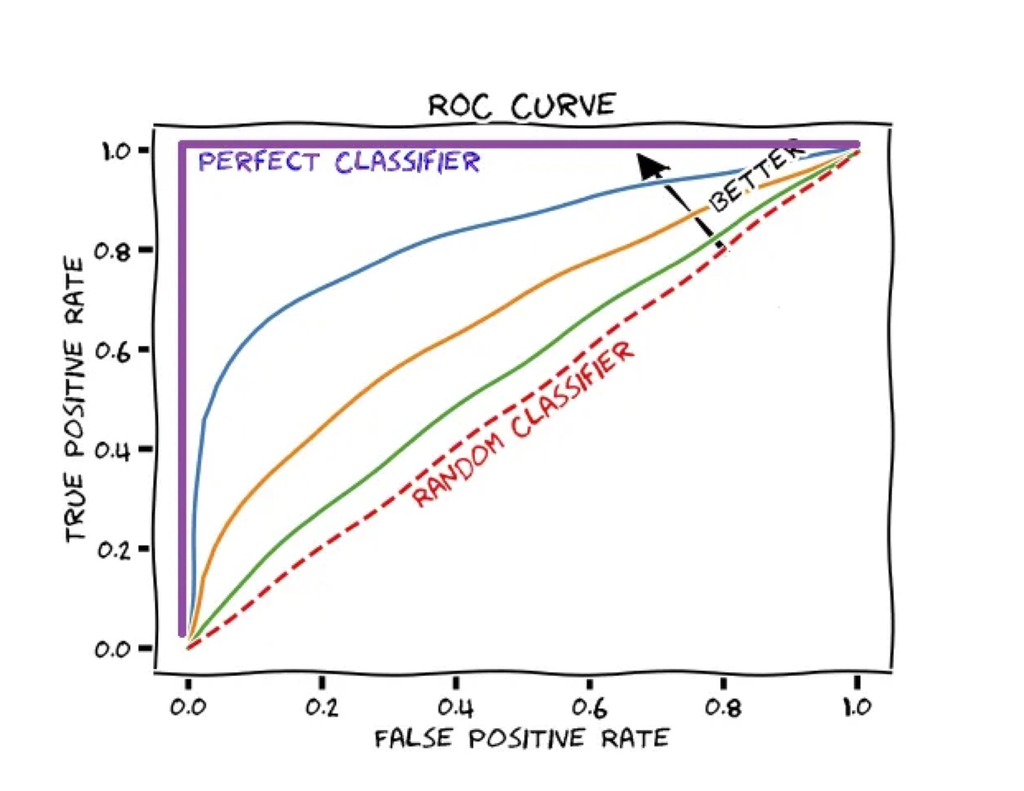

# Model Evaluation

It’s time to load our models back in to evaluate their results!

```r
load(file= "~/Desktop/School/PSTAT/PSTAT 131/proj-final/rda_files/logistic.rda")
load(file= "~/Desktop/School/PSTAT/PSTAT 131/proj-final/rda_files/knn.rda")
load(file= "~/Desktop/School/PSTAT/PSTAT 131/proj-final/rda_files/en.rda")
load(file= "~/Desktop/School/PSTAT/PSTAT 131/proj-final/rda_files/lda.rda")
load(file= "~/Desktop/School/PSTAT/PSTAT 131/proj-final/rda_files/qda.rda")
load(file= "~/Desktop/School/PSTAT/PSTAT 131/proj-final/rda_files/decision-tree.rda")
```

## Model Autoplots

Here, we will visualize the results of our tuned models. We will use the `autoplot` function to visualize the effect of varying select parameters on the performance of each model according to its impact on our metric of choice.

### K-Nearest Neighbors

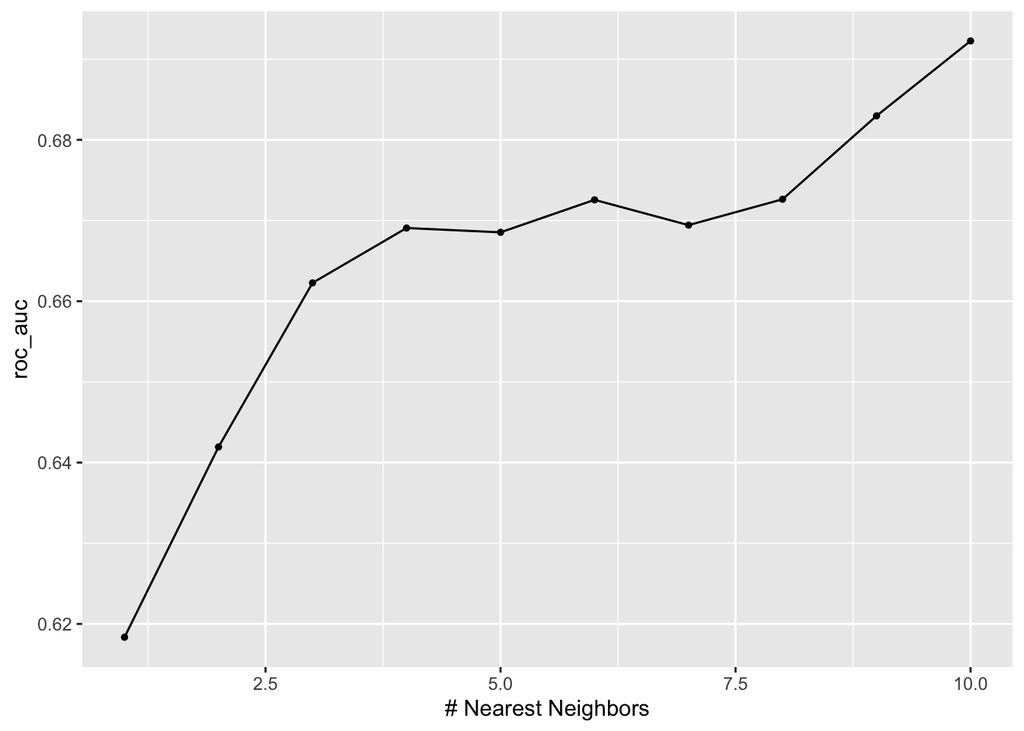

```r
autoplot(knn_tune_res)
```

### Elastic Net

In our elastic net model, we tuned 2 parameters with 10 levels of each: `penalty`, the amount of regularization, and `mixture`, the proportion of lasso penalty (1 for pure lasso, 0 for pure ridge). We can see from the graph that the optimal mixture was 0 (pure ridge). Lower levels of mixture resulted in higher `roc_auc` scores, and that models performed worse as `penalty` (amount of regularization) increased.

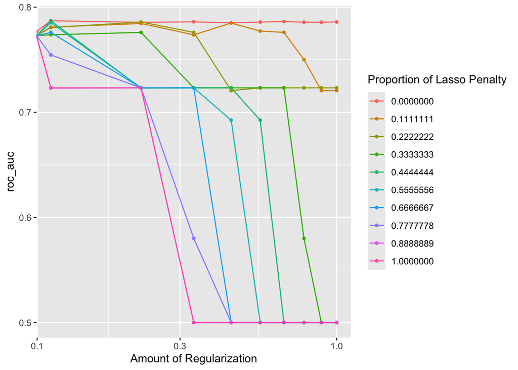

```r
autoplot(en_tune_res)
```

### Decision Tree

For our decision tree model, we focused on tuning the `cost_complexity` parameter with 10 levels. Decision trees can often become too complex, leading to overfitting. A simpler model (smaller tree) with fewer splits can improve interpretability with the trade-off of introducing more bias.

The idea of cost-complexity pruning is similar to that of lasso / ridge regularization: we first grow a large tree, then prune it by selecting the sub-tree that minimizes a penalized error metric. The `cost_complexity` parameter balances model complexity with fit to the data. A value of 0 is the same as the training error rate; increasing it penalizes the tree for having too many nodes.

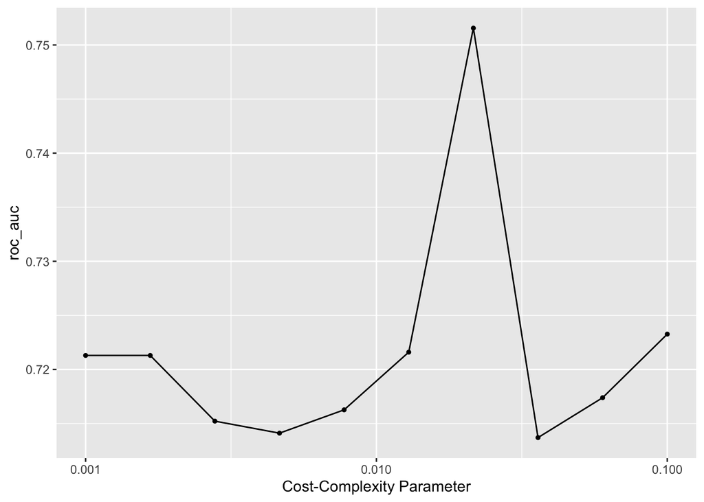

```r
autoplot(dt_tune_res)
```

## Model Selection

Here, we will compare the performance of each model on the training data and visualize the results. To do this, I’ve created a tibble to display the estimated testing `roc_auc` scores for each fitted model.

```r
log_auc <- augment(log_fit, new_data = loan_train) %>%
  roc_auc(truth = Loan_Status, .pred_Yes) %>%
  select(.estimate)

lda_auc <- augment(lda_fit, new_data = loan_train) %>%
  roc_auc(truth = Loan_Status, .pred_Yes) %>%
  select(.estimate)

qda_auc <- augment(qda_fit, new_data = loan_train) %>%
  roc_auc(truth = Loan_Status, .pred_Yes) %>%
  select(.estimate)

knn_auc <- augment(knn_final_fit, new_data = loan_train) %>%
  roc_auc(truth = Loan_Status, .pred_Yes) %>%
  select(.estimate)

en_auc <- augment(en_final_fit, new_data = loan_train) %>%
  roc_auc(truth = Loan_Status, .pred_Yes) %>%
  select(.estimate)

dt_auc <- augment(dt_final_fit, new_data = loan_train) %>%
  roc_auc(truth = Loan_Status, .pred_Yes) %>%
  select(.estimate)



roc_aucs <- c(log_auc$.estimate,
                           lda_auc$.estimate,
                           qda_auc$.estimate,
                           knn_auc$.estimate,
                           en_auc$.estimate,
                           dt_auc$.estimate)

mod_names <- c("Logistic Regression",
            "LDA",
            "QDA",
            "KNN",
            "Elastic Net",
            "Decision Tree")
```

```r
mod_results <- tibble(Model = mod_names,
                             ROC_AUC = roc_aucs)

mod_results <- mod_results %>%
  dplyr::arrange(-roc_aucs)

mod_results
```

| Model | ROC_AUC |
| --- | --- |
| KNN | 0.9417152 |
| QDA | 0.8609664 |
| Elastic Net | 0.8238553 |
| LDA | 0.8232482 |
| Logistic Regression | 0.8226410 |
| Decision Tree | 0.8167215 |

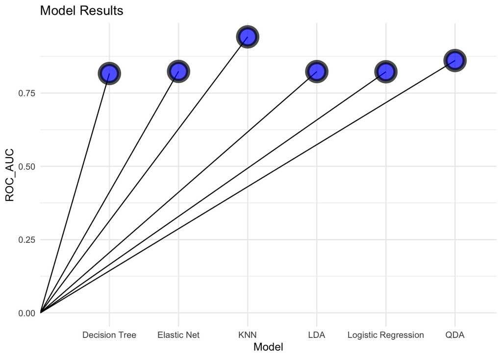

```r
lp_plot <- ggplot(mod_results, aes(x = Model, y = ROC_AUC)) +
    geom_segment( aes(x = Model, xend = 0, y = ROC_AUC, yend = 0)) +
  geom_point( size=7, color= "black", fill = alpha("blue", 0.3), alpha=0.7, shape=21, stroke=3) +
  labs(title = "Model Results") +
  theme_minimal()

lp_plot
```

# Model Validation

## KNN Model

### Performance on the folds

The KNN model performed best overall, but which of value of `neighbors` yields the best performance?

We identify that KNN Model 10 with 11 predictors, 10 neighbors, and a mean `roc_auc` score of 0.69, performed the best! Now that we have our best model, we can fit it to our testing data to evaluate its true predictive power.

```r
# select metrics of best knn model
knn_tune_res %>%
  collect_metrics() %>%
  dplyr::arrange(mean) %>%
  slice(10)
```

| neighbors | .metric | .estimator | mean | n | std_err | .config |
| --- | --- | --- | --- | --- | --- | --- |
| 10 | roc_auc | binary | 0.6922584 | 10 | 0.02660604 | Preprocessor1_Model10 |

### Testing the model

```r
knn10_roc_auc <- augment(knn_final_fit, new_data = loan_test) %>%
  roc_auc(Loan_Status, .pred_Yes)  %>%
  select(.estimate)

knn10_roc_auc
```

| .estimate |
| --- |
| 0.6797448 |

### ROC curve

Below is a confusion matrix of the test results as well as an ROC/AUC plot.

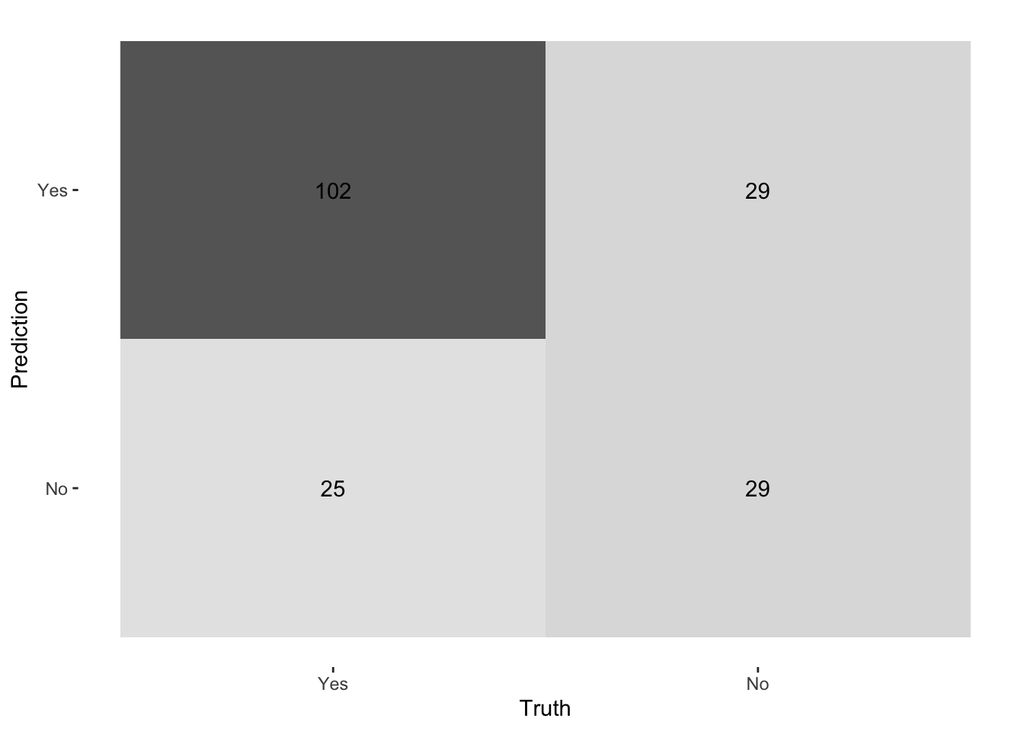

```r
knn_test_results <- augment(knn_final_fit, new_data = loan_test)

knn_test_results %>%
  conf_mat(truth = Loan_Status, estimate = .pred_class) %>%
  autoplot(type = "heatmap")
```

In general, the more an ROC curve resembles the top left angle of a square, the better the AUC. While our curve is not perfect, it has the correct shape and looks pretty decent.

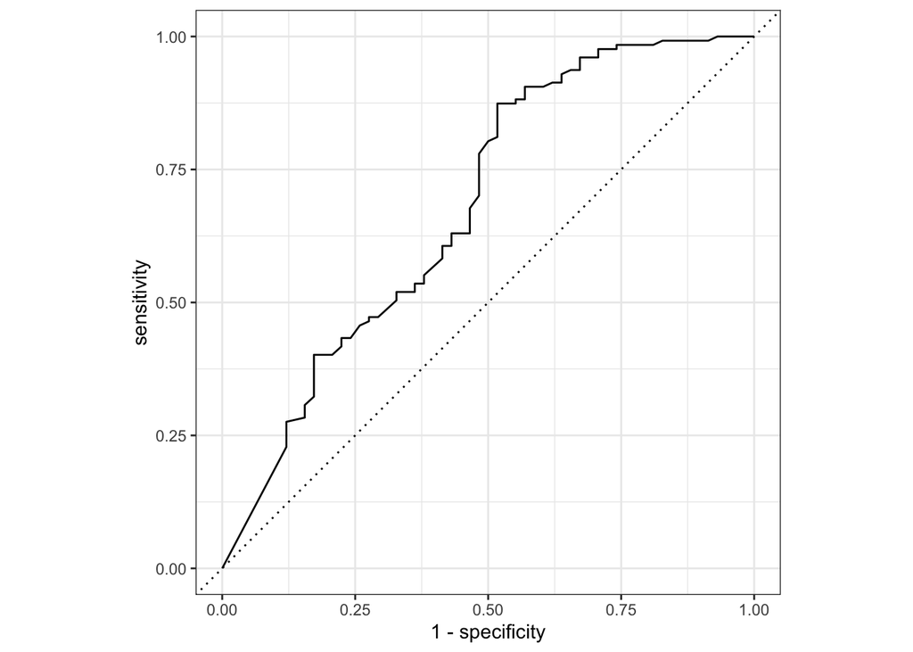

```r
knn_test_results %>%
  roc_curve(Loan_Status, .pred_Yes) %>%
  autoplot()
```

Here’s a distribution of the predicted probabilities.

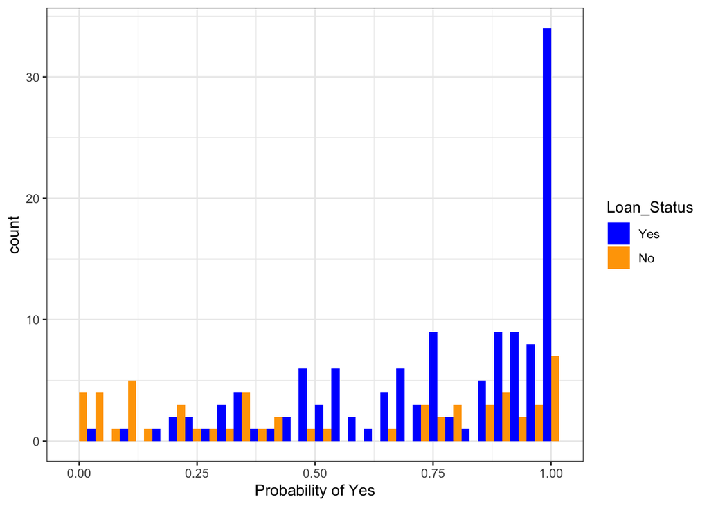

```r
knn_test_results %>%
  ggplot(aes(x = .pred_Yes, fill = Loan_Status)) +
  geom_histogram(position = "dodge") + theme_bw() +
  xlab("Probability of Yes") +
  scale_fill_manual(values = c("blue", "orange"))
```